# R Notebook

OVERALL SETUP

```r
options(warn=-1)

library(tidyverse)
library(quanteda)
library(quanteda.textstats)
library(quanteda.textmodels)
library(lexicon)
library(caret)
library(ggplot2)
library(stringr)
library(reshape2)

setwd('C:/Users/arzaa/teda_project')


reviews <- read_csv('zocdoc_data.csv', show_col_types = FALSE)
reviews_dfm <- reviews$Review %>%  tokens(remove_punct=TRUE, remove_numbers=TRUE, remove_symbols=TRUE) %>% tokens_tolower() %>%  tokens_replace(pattern=hash_lemmas$token, replacement=hash_lemmas$lemma) %>% tokens_select(pattern = stopwords("en"), selection = "remove") %>% dfm()
head(reviews)
```

| ...1 | DocName | Specialty | PatientName | ReviewDate | OverallRating | Review |
| --- | --- | --- | --- | --- | --- | --- |
| 0 | Dr. Liana Dao | Family Physician | Ashley M. (Verified Patient) | April 7 2015 | 5 | Liana Dao is amazing ! She made me feel totally comfortable and answered all my questions. I was in and out. No wait time. The medical assistant at the desk was also very sweet. I definitely will come… |
| 1 | Dr. Liana Dao | Family Physician | a Verified Patient | April 6 2015 | 5 | I was in a jam and couldn't get to my regular GP. Don't be put off by location. Dr. Dao was prompt friendly knowledgeable and thorough. She explained the test she took showing me the actual results. S… |
| 2 | Dr. Liana Dao | Family Physician | a Verified Patient | Less than a year ago | 5 | Dr. Dao was great - she took the time to explain my diagnosis and her associate (admin/nurse) was very friendly and helpful as well. |
| 3 | Dr. Liana Dao | Family Physician | a Verified Patient | August 5 2014 | 5 | Very knowledgeable and explained everything. Professional and acted courteously. Didn't feel rushed but was in and out quickly. |
| 4 | Dr. Liana Dao | Family Physician | a Verified Patient | May 5 2014 | 5 | Liana was very pleasant and easy to deal with. She got straight to the point and I was in and out with a solution quickly. |
| 5 | Dr. Liana Dao | Family Physician | a Verified Patient | More than a year ago | 1 | First issue is they don't tell you that this is at the bottom of a Duane Reade so I spent 10 minutes trying to figure that out. Second issue is they had no record of my appointment and were on a lunch… |

```r
# To make a corpus after selecting a subset from the tibble
make_corpus_or_tokenize <- function(x, remove_stop=TRUE, lemmatize=TRUE, tolower=TRUE, remove_punct=TRUE, tokenize=FALSE) {
  # x should be (a subset of) reviews$Review
  corp <- x %>% tokens(remove_punct=remove_punct, remove_numbers=TRUE, remove_symbols=TRUE)

  if (tolower) {
    corp <- corp %>% tokens_tolower()
  }

  if (remove_stop) {
    corp <- corp %>% tokens_select(pattern = stopwords("en"), selection = "remove")
  }

  if (lemmatize) {
    corp <- corp %>% tokens_replace(pattern=hash_lemmas$token, replacement=hash_lemmas$lemma)
  }

  if (tokenize) {
    return(corp)
  }
  corp %>% corpus()
}

token_count <- function(x, n=20, remove_stop=TRUE, lemmatize=TRUE, tolower=TRUE, remove_punct=TRUE) {
  # x should be (a subset of) reviews$Review
  x_dfm <- x %>% make_corpus_or_tokenize(remove_stop=remove_stop, lemmatize=lemmatize, tolower=tolower, remove_punct=remove_punct, tokenize=TRUE) %>% dfm()
  textstat_frequency(x_dfm, n=n)
}
```

# Basic statistics of the corpus

```r
avg_len = reviews$Review %>% tokens() %>% lapply(FUN=length) %>% unlist() %>% unname() %>% mean() %>% round()
paste('Size of corpus:', nrow(reviews))
```

```
## [1] "Size of corpus: 21962"
```

```r
paste('Average length of documents:', avg_len)
```

```
## [1] "Average length of documents: 34"
```

```r
paste('# unique tokens after lemmatization and removal of stopwords:', ncol(reviews_dfm))
```

```
## [1] "# unique tokens after lemmatization and removal of stopwords: 10015"
```

# Analyzing tokens, bigrams, etc

**Most common tokens overall**

```r
tc <- token_count(reviews$Review, n=30)
tc
```

|  | feature | frequency | rank | docfreq | group |
| --- | --- | --- | --- | --- | --- |
| 1 | dr | 10409 | 1 | 8630 | all |
| 2 | doctor | 8435 | 2 | 6809 | all |
| 3 | good | 5533 | 3 | 4767 | all |
| 4 | great | 5525 | 4 | 4951 | all |
| 5 | time | 5251 | 5 | 4417 | all |
| 6 | feel | 4034 | 6 | 3503 | all |
| 7 | recommend | 3942 | 7 | 3858 | all |
| 8 | office | 3855 | 8 | 3140 | all |
| 9 | professional | 3807 | 9 | 3685 | all |
| 10 | care | 3640 | 10 | 3161 | all |

[output cut: 20 more lines]

Among the meaningful words in this result, we find “time,” “feel,” “office,” “professional,” and “care.” Time, feel, and professional reveal several more obvious priorities patients have when visiting a doctor - how much time in takes (i.e. the wait AND the visit itself - more on the latter below), how the doctor makes them feel (though this token may also included instances of “I felt ill”), and how professionally the doctor acts. Less obvious but still logical was “office,” as the quality of the office is apparently important to the patient experience, and “care.” This last word is difficult to infer anything from on its own and requires deeper investigation. At rank 12, “staff” also makes an appearance, revealing that the doctor’s additional staff - nurses, receptionists, etc. - matter to the patient’s review as well.

**Most common collocations**

```r
reviews_corpus <- reviews$Review %>% tokens() %>%  tokens_replace(pattern=hash_lemmas$token, replacement=hash_lemmas$lemma) %>% tokens_select(pattern = stopwords("en"), selection = "remove")
collocs <- textstat_collocations(reviews_corpus)
collocs
```

|  | collocation | count | count_nested | length | lambda | z |
| --- | --- | --- | --- | --- | --- | --- |
| 1 | take time | 1594 | 0 | 2 | 4.2879873 | 108.876681 |
| 2 | make feel | 1260 | 0 | 2 | 4.5740077 | 105.016927 |
| 3 | highly recommend | 1875 | 0 | 2 | 7.2003595 | 103.854379 |
| 4 | answer question | 1025 | 0 | 2 | 6.4631175 | 89.404245 |
| 5 | feel comfortable | 1007 | 0 | 2 | 5.2140949 | 88.668585 |
| 6 | easy talk | 491 | 0 | 2 | 6.1386105 | 79.996688 |
| 7 | primary care | 776 | 0 | 2 | 5.5013130 | 78.558760 |
| 8 | go back | 522 | 0 | 2 | 4.3389124 | 71.904865 |
| 9 | wait time | 789 | 0 | 2 | 3.1797262 | 70.690440 |
| 10 | feel like | 608 | 0 | 2 | 3.6845921 | 69.501096 |

[output cut: 9990 more lines]

“Take time” is on top, which already informs my preconceptions on what people like in a doctor. Naturally, they want a short wait (“wait time” is #9, and a future look at some keywords in context will likely reveal words such as “short” or “long” nearby); that said, once the doctor is actually seeing you, reviewers don’t want the visit to end ASAP. This collocation implies that they prefer that phase to be thorough - a logical result. It’s worth investigation how common “take time” is among positive reviews specifically.

# Analysis by positive/negative

**Analyzing by DOCUMENT frequency: Which words have the highest/lowest occurrence ratio for pos/neg docs?**

```r
reviews_pos <- reviews %>% filter(OverallRating >= 4)
reviews_neg <- reviews %>% filter(OverallRating < 4)

# Get frequencies
# Use more terms in token count so we can catch those which
# are common in one class but rare in another
pos_freqs <- token_count(reviews_pos$Review, n=200) %>% tibble() %>%  mutate(docfreq = docfreq/sum(docfreq))

neg_freqs <- token_count(reviews_neg$Review, n=200) %>% tibble() %>%  mutate(docfreq = docfreq/sum(docfreq))

# Join by feature (token)
# Some terms will be absent from one class. After join, impute
# these with some small number so no division by 0 occurs
# Impute value is 1/10 of the lowest docfreq
freqs <- full_join(pos_freqs, neg_freqs, by="feature", suffix=c('.pos','.neg')) %>% mutate(docfreq.pos = ifelse(is.na(docfreq.pos), min(docfreq.pos, na.rm=TRUE)/10, docfreq.pos)) %>% mutate(docfreq.neg = ifelse(is.na(docfreq.neg), min(docfreq.neg, na.rm=TRUE)/10, docfreq.neg)) %>%  mutate(ratio=docfreq.pos/docfreq.neg) %>% select(c(feature, ratio)) %>% arrange(desc(ratio))

# More common in positive than negative
freqs[1:20,]
```

| feature | ratio |
| --- | --- |
| highly | 80.26519 |
| excellent | 55.83505 |
| comfortable | 54.69104 |
| knowledgeable | 48.49124 |
| definitely | 43.98901 |
| always | 43.32475 |
| personable | 36.86663 |
| attentive | 36.75592 |
| easy | 35.72262 |
| everything | 34.72623 |

[output cut: 10 more lines]

```r
# More common in negative than positive
freqs[(nrow(freqs)-19):nrow(freqs),]
```

| feature | ratio |
| --- | --- |
| fill | 0.04536964 |
| place | 0.04536964 |
| okay | 0.04536964 |
| waste | 0.04536964 |
| something | 0.04536964 |
| fine | 0.04536964 |
| finally | 0.04226213 |
| walk | 0.04169102 |
| bill | 0.04059389 |
| end | 0.03905235 |

[output cut: 10 more lines]

Same thing but with collocations:

```r
make_collocs <- function(x, pos=TRUE) {
  if (pos) {
    corp <- reviews %>% filter(OverallRating >= 4)
  }
  else {
    corp <- reviews %>% filter(OverallRating < 4)
  }
  corp$Review %>%  tokens(remove_punct=TRUE, remove_numbers=TRUE) %>%  tokens_replace(pattern=hash_lemmas$token, replacement=hash_lemmas$lemma) %>% tokens_select(pattern = stopwords("en"), selection = "remove") %>% textstat_collocations() %>% arrange(desc(count))
}

pos_collocs <- make_collocs(reviews)
neg_collocs <- make_collocs(reviews, pos=FALSE)

pos_collocs
```

|  | collocation | count | count_nested | length | lambda | z |
| --- | --- | --- | --- | --- | --- | --- |
| 3 | highly recommend | 1869 | 0 | 2 | 6.839387e+00 | 1.000399e+02 |
| 1 | take time | 1567 | 0 | 2 | 4.674587e+00 | 1.109214e+02 |
| 2 | make feel | 1200 | 0 | 2 | 4.416955e+00 | 1.014912e+02 |
| 4 | answer question | 998 | 0 | 2 | 6.442019e+00 | 9.108670e+01 |
| 5 | feel comfortable | 984 | 0 | 2 | 5.273079e+00 | 9.031267e+01 |
| 46 | bedside manner | 911 | 0 | 2 | 1.053694e+01 | 4.153779e+01 |
| 23 | great doctor | 834 | 0 | 2 | 2.110831e+00 | 5.263177e+01 |
| 7 | primary care | 715 | 0 | 2 | 5.439006e+00 | 7.639742e+01 |
| 9 | wait time | 678 | 0 | 2 | 3.371077e+00 | 6.898132e+01 |
| 52 | good doctor | 615 | 0 | 2 | 1.817657e+00 | 4.023971e+01 |

[output cut: 9990 more lines]

```r
neg_collocs
```

|  | collocation | count | count_nested | length | lambda | z |
| --- | --- | --- | --- | --- | --- | --- |
| 1 | feel like | 126 | 0 | 2 | 4.3312094055 | 35.349362086 |
| 2 | go back | 118 | 0 | 2 | 3.8773878937 | 32.159854811 |
| 10 | wait time | 113 | 0 | 2 | 2.7697889156 | 25.027745814 |
| 16 | see doctor | 105 | 0 | 2 | 2.5829386786 | 22.703046255 |
| 4 | come back | 81 | 0 | 2 | 4.0632650254 | 28.751060877 |
| 13 | wait hour | 76 | 0 | 2 | 3.3933465125 | 24.205599222 |
| 3 | blood work | 74 | 0 | 2 | 4.6959395053 | 29.979185052 |
| 5 | ask question | 71 | 0 | 2 | 4.2083255212 | 27.425646214 |
| 18 | make appointment | 68 | 0 | 2 | 3.1203624373 | 22.086814398 |
| 46 | bedside manner | 68 | 0 | 2 | 10.9607522210 | 16.210654722 |

[output cut: 6454 more lines]

**What are the most common words with a positive/negative connotation? Note that this is analyzed irrespective of review class**

```r
reviews_toks <- make_corpus_or_tokenize(reviews$Review, tokenize=TRUE)

paste('Positive features')
```

```
## [1] "Positive features"
```

```r
pos_feats <- tokens_select(reviews_toks, pattern = data_dictionary_LSD2015["positive"]) %>%
  dfm() %>%
  topfeatures()
pos_feats
```

```
##        good       great        care    thorough    friendly        nice
##        5533        5525        3640        2983        2982        2365
##        like     helpful   excellent comfortable
##        2096        1634        1567        1547
```

```r
paste('')
```

```
## [1] ""
```

```r
paste('Negative features')
```

```
## [1] "Negative features"
```

```r
neg_feats <- tokens_select(reviews_toks, pattern = data_dictionary_LSD2015["negative"]) %>%
  dfm() %>%
  topfeatures()
neg_feats
```

```
##      wait   concern     blood   problem      bite       bad      rude      pain
##      3005      1797       782       654       418       296       212       178
##     wrong complaint
##       160       147
```

**What negative words pop up in 5-star reviews?**

```r
reviews_toks_5 <- reviews %>% filter(OverallRating==5) %>% select(Review) %>% pull() %>%  make_corpus_or_tokenize(tokenize=TRUE)
tokens_select(reviews_toks_5, pattern = data_dictionary_LSD2015["negative"]) %>%
  dfm() %>%
  topfeatures(n=20)
```

```
##      wait   concern   problem     blood      bite       bad      hard complaint
##      1825      1556       517       400       236       110       103       103
##   illness      pain     wrong   nervous      numb      sick   ailment     worry
##        94        93        87        85        75        75        62        56
## difficult emergency      rude    injury
##        48        48        45        45
```

Would need to do collocations for the above to have proper context. “wait” could be “short wait,” for instance

# Analysis by specialty

First off: What specialties are there, and how many doctors for each?

```r
reviews %>% group_by(Specialty) %>% summarise(count_revs=n(), count_docs=n_distinct(DocName)) %>% arrange(desc(count_revs))
```

| Specialty | count_revs | count_docs |
| --- | --- | --- |
| NA | 15874 | 481 |
| Internist | 2095 | 34 |
| Primary Care Doctor | 2041 | 36 |
| Gastroenterologist | 370 | 9 |
| Family Physician | 257 | 5 |
| Travel Medicine Specialist | 165 | 3 |
| Nephrologist | 159 | 2 |
| Infectious Disease Specialist | 158 | 5 |
| Pulmonologist | 140 | 2 |
| Cardiologist | 105 | 2 |

[output cut: 11 more lines]

Multiple things are revealed about our data here. For one, most doctors has no specialty listed. This is either a limitation of Zocdoc, which may not have required this field at the time, or a flaw in the scraping procedure that gathered this data. One way or another, I will limit analysis to those doctors with a specialty listed. Naturally, some specialties are more rare than others, which limits our ability to infer if there are any particular qualities more desirable in a neurologist, for instance. To keep the scope of the problem reasonable, I will limit analysis to the top 5 specialties by count.

```r
specialties <- reviews %>% group_by(Specialty) %>% summarise(count=n()) %>% filter(count >= 80) %>% filter(!is.na(Specialty)) %>% arrange(desc(count)) %>% select(Specialty) %>% slice_head(n=5)
reviews_subset <- reviews %>% filter(Specialty %in% specialties$Specialty)
```

**Similar to pos/neg above: Which words appear more in one specialty that in others?**

The ratio metric here is less obvious since there are multiple classes. I’ll use document frequency in the given specialty divided by all other document frequencies.

```r
# Since we are grouping we can't just pass the reviews
# x is the df minus the group variable, y is the group var value
token_count_group <- function(x, y, n=200, remove_stop=TRUE, lemmatize=TRUE, tolower=TRUE, remove_punct=TRUE) {


  corp <- x$Review %>% tokens(remove_punct=remove_punct)

  if (tolower) {
    corp <- corp %>% tokens_tolower()
  }

  if (remove_stop) {
    corp <- corp %>% tokens_select(pattern = stopwords("en"), selection = "remove")
  }

  if (lemmatize) {
    corp <- corp %>% tokens_replace(pattern=hash_lemmas$token, replacement=hash_lemmas$lemma)
  }

  corp <- corp %>% dfm() %>% textstat_frequency(n=n) %>% tibble() %>%  mutate(Specialty=y$Specialty[1], docfreq=docfreq/sum(docfreq))
  corp[c('feature','docfreq','Specialty')]
}

# bind_rows can make a list of tibbles into a single tibble
res <- reviews_subset %>% group_by(Specialty) %>% group_map(token_count_group) #%>% bind_rows()
#res

# Now calculate ratios... somehow
# I guess don't rbind, but join them with their specialty as suffix?
# Then impute
# Then, for each row, take the highest docfreq and divide it by
# the sum of the rest?

# Set suffix on docfreq asap so don't have to worry about join sufic
df <- res[[1]]
colnames(df)[2] <- paste(colnames(df)[2], '.', df$Specialty[1], sep='')
df <- df[c('feature','docfreq.Family Physician')]

# Do the joins, and change docfreq's name as it is added
for (i in 2:length(res)) {
  next_tibble <- res[[i]][c('feature','docfreq')]
  df <- full_join(df, next_tibble, by='feature')
  new_name <- paste('docfreq.', res[[i]]$Specialty[1], sep='')
  df <- rename(df, !!new_name:=docfreq)
}

# Impute each col with 1/10 of its minimum value, as before
# Actually, might be better to each ROW by 1/10 of its min
# Or maybe 1/10 of the global min?
docfreq_cols <- colnames(df)[-1]
df[is.na(df)] <- min(df[docfreq_cols], na.rm = TRUE)/10

# Get which cols have the highest docfreq per word
colmaxes <- max.col(df[,-1])+1 # add 1 to get actual column index in df

# Initialize cols to be filled in with results
df <- df %>% mutate(ratio=0, maxcol='a')

for (i in 1:nrow(df)) {
  # Divide highest ratio in row by mean of other ratios
  df$ratio[i] <- df[i,colmaxes[i]] %>% pull() / rowMeans(df[i,-c(1,colmaxes[i],7,8)])
  # Safe which column that ratio belongs to
  df$maxcol[i] <- docfreq_cols[colmaxes[i]-1]
}
```

```r
myfunc <- function(x, y) {
  #paste('Most common for' str_split(y %>% pull())[2])
  spec <- (y %>% pull() %>% str_split('\\.'))[[1]][2]
  #print(spec)
  x %>% arrange(desc(ratio)) %>% select(feature, ratio) %>% mutate(Specialty=spec)
}
df %>% group_by(maxcol) %>% group_map(myfunc)
```

```
## [[1]]
## # A tibble: 75 x 3
##    feature    ratio Specialty
##    <chr>      <dbl> <chr>
##  1 rao        126.  Family Physician
##  2 injury      40.6 Family Physician
##  3 past        36.5 Family Physician
##  4 life        32.4 Family Physician
##  5 calm        32.4 Family Physician
##  6 option      28.4 Family Physician
##  7 clear       28.4 Family Physician
##  8 open        24.3 Family Physician
##  9 thoughtful  24.3 Family Physician
## 10 portal      24.3 Family Physician
## # ... with 65 more rows
##
## [[2]]
## # A tibble: 76 x 3
##    feature    ratio Specialty
##    <chr>      <dbl> <chr>
##  1 pashinsky  127.  Gastroenterologist
##  2 crespin    103.  Gastroenterologist
##  3 warman      60   Gastroenterologist
##  4 koutsos     60   Gastroenterologist
##  5 procedure   46.7 Gastroenterologist
##  6 person      40   Gastroenterologist
##  7 antosofsky  33.3 Gastroenterologist
##  8 smart       33.3 Gastroenterologist
##  9 sweet       23.3 Gastroenterologist
## 10 fill        20   Gastroenterologist
## # ... with 66 more rows
##
## [[3]]
## # A tibble: 41 x 3
##    feature ratio Specialty
##    <chr>   <dbl> <chr>
##  1 hago     27.5 Internist
##  2 milani   21.2 Internist
##  3 kalik    21.2 Internist
##  4 nikrouz  19.5 Internist
```

[output cut: 24 more lines]

```
## [[5]]
## # A tibble: 93 x 3
##    feature     ratio Specialty
##    <chr>       <dbl> <chr>
##  1 pa           91.3 Travel Medicine Specialist
##  2 saltzman     85.6 Travel Medicine Specialist
##  3 acupuncture  34.2 Travel Medicine Specialist
##  4 kumar        28.5 Travel Medicine Specialist
##  5 cover        28.5 Travel Medicine Specialist
##  6 doctor's     28.5 Travel Medicine Specialist
##  7 light        28.5 Travel Medicine Specialist
##  8 attention    28.5 Travel Medicine Specialist
##  9 end          28.5 Travel Medicine Specialist
## 10 write        22.8 Travel Medicine Specialist
## # ... with 83 more rows
```

# Modeling rating from review

There are two ways that we can model rating: we can either do a multiclass problem with all 5 ratings, or binarize the labels as we did in the positive/negative analysis. There are various considerations to be made either way. If we stick with the labels as-is, then we have a class imbalance problem:

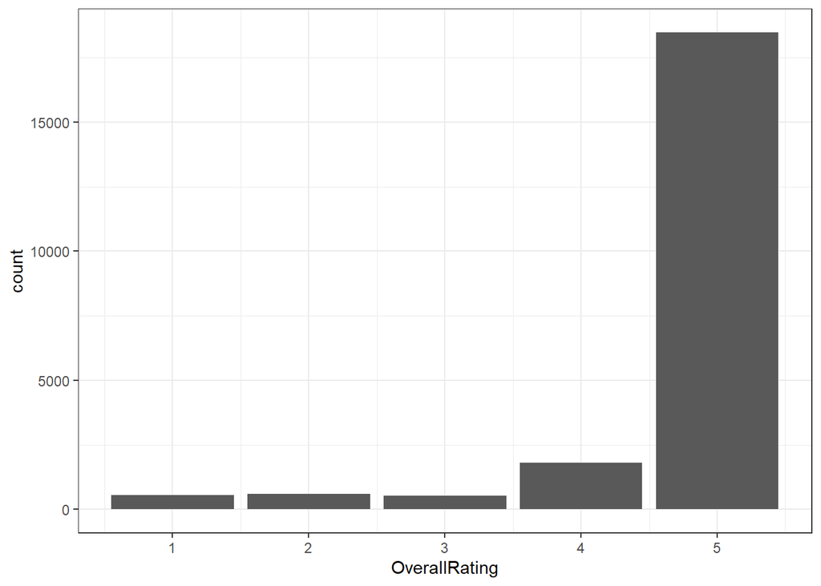

```r
ggplot(reviews, mapping=aes(OverallRating)) +
  geom_bar()+
  theme_bw()
```

We have far more 5 star reviews than any other number. There are various psychological reasons why a patient may choose a 5-star review, aside from that the visit was truly perfect. For instance, if a doctor has a 4.5 and the patient felt that there were only minor issues, the patient may be unwilling to give a 4, as this would lower the doctor’s average. Simple generosity could be at play, as well: “This person helped me, so now I will help them by giving a 5.” Or it could be that patients have a high standard for what must go wrong in order for a doctor to “deserve” an imperfect score. Regardless of the reason, class imbalance will make it easy for our model to achieve high accuracy. ’ What if we binarize the label? When I did word frequency analysis, I chose to define reviews >= 4 as positive, and < 4 as negative. That is one option, but there are other ways to binarize as well; one such framing would be to make it an question of 5 stars vs. not 5 stars, which would capture the question of “Did the patient find the visit perfect or not?” We could even generate our own labels for this question: if the review has no negative sentiment words we could place it in the positive (“perfect”) class, and vice-versa.

For now, I’ll start by predicting the rating from 1-5:

**Naive Bayes**

SETUP CELL FOR MODELING

```r
make_dfm <- function(x) {
  x %>% tokens(remove_punct=TRUE, remove_numbers=TRUE, remove_symbols=TRUE) %>% tokens_tolower() %>%  tokens_replace(pattern=hash_lemmas$token, replacement=hash_lemmas$lemma) %>% tokens_select(pattern = stopwords("en"), selection = "remove") %>% dfm()
}

reviews$target <- factor(reviews$OverallRating >= 4)

# train/val/test split
set.seed(111)
id_trainval <- sample(1:nrow(reviews), 0.7*nrow(reviews), replace=FALSE)
id_val <- sample(id_trainval, 0.15/0.7*length(id_trainval), replace=FALSE)
id_train <- setdiff(id_trainval, id_val)
id_test <- setdiff(1:nrow(reviews), id_trainval)

X_train <- reviews[id_train,]$Review %>% make_dfm()
y_train <- reviews$OverallRating[id_train]
X_val <- reviews[id_val,]$Review %>% make_dfm() %>% dfm_match(featnames(X_train))
y_val <- reviews$OverallRating[id_val]
X_test <- reviews[id_test,]$Review %>% make_dfm() %>% dfm_match(featnames(X_train))
y_test <- reviews$OverallRating[id_test]

# Set up functions for evaluation
eval_nb <- function(mod, Xt, yt) {
  preds <- predict(mod, Xt)

  # Evaluate on test and assess confusion matrix
  paste('Accuracy:', sum(preds==yt)/length(preds))

  if ( length(unique(yt))  > 2 ) {
    cmat <- confusionMatrix(preds, factor(yt))
  }
  else {
    cmat <- confusionMatrix(preds, factor(yt), positive="TRUE")
  }

  cmat
}

over_under_nb <- function(mod, Xt, yt) {
  preds <- predict(mod, Xt)

  metrics <- tibble(preds, yt) %>% group_by(yt) %>% summarise(underpredict=sum(as.numeric(preds)<as.numeric(yt))/n(), overpredict=sum(as.numeric(preds)>as.numeric(yt))/n(), count=n(), correct=sum(as.numeric(preds)==as.numeric(yt))/n()) %>% rename(OverallRating=yt)

metrics[c('OverallRating','underpredict','overpredict','correct','count')]
}

# Gets the top terms by model coefficient for each rating
get_top_terms <- function(mod, n=20) {
  melt(coef(mod)) %>% rename(feature=Var1, Class=Var2, coefficient=value) %>% data.frame() %>% group_by(Class) %>% group_map(coef_func, n=n)
}


# Accessory function to the above, gets top n coefficients by group
coef_func <- function(x, y, n=20) {
  x %>% arrange(desc(coefficient)) %>% slice_head(n=n) %>% mutate(Class=y %>% pull())
}
```

**Modeling without downsampling or binarizing**

```r
# Hyperparameters include prior and distribution
params <- expand_grid(c('uniform','docfreq','termfreq'), c('Bernoulli','multinomial'))
colnames(params) <- c('prior', 'distribution')
params$acc <- 0 # Will be filled in as we loop

for (i in 1:nrow(params)) {
  mod_nb <- textmodel_nb(X_train, y_train,
                         prior=params$prior[i],
                         distribution=params$distribution[i])
  preds <- predict(mod_nb, newdata=X_val)
  params$acc[i] <- sum(preds == y_val) / length(preds)
}
params
```

| prior | distribution | acc |
| --- | --- | --- |
| uniform | Bernoulli | 0.8181542 |
| uniform | multinomial | 0.8391014 |
| docfreq | Bernoulli | 0.8354584 |
| docfreq | multinomial | 0.8588342 |
| termfreq | Bernoulli | 0.8357620 |
| termfreq | multinomial | 0.8582271 |

Winner: (docfreq, multinomial). Docfreq makes sense due to the class imbalance

```r
# Retrain best model on train AND val data, get test preds
X_trainval <- rbind(X_train, X_val)
y_trainval <- c(y_train, y_val)
mod_nb <- textmodel_nb(X_trainval,
                       y_trainval,
                       prior='docfreq',
                       distribution='multinomial')

eval_nb(mod_nb, X_test, y_test)
```

```
## Confusion Matrix and Statistics
##
##           Reference
## Prediction    1    2    3    4    5
##          1   86   53   16   10   16
##          2   19   33   11    6   10
##          3    2    2    6    1    6
##          4    9   30   40   87   80
##          5   34   71   96  431 5434
##
## Overall Statistics
##
##                Accuracy : 0.8569
##                  95% CI : (0.8482, 0.8653)
##     No Information Rate : 0.8417
##     P-Value [Acc > NIR] : 0.0003375
##
##                   Kappa : 0.3525
##
##  Mcnemar's Test P-Value : < 2.2e-16
##
## Statistics by Class:
##
##                      Class: 1 Class: 2  Class: 3 Class: 4 Class: 5
## Sensitivity           0.57333 0.174603 0.0355030  0.16262   0.9798
## Specificity           0.98525 0.992812 0.9982866  0.97374   0.3941
## Pos Pred Value        0.47514 0.417722 0.3529412  0.35366   0.8958
## Neg Pred Value        0.99001 0.976037 0.9751978  0.92937   0.7859
## Prevalence            0.02277 0.028684 0.0256488  0.08120   0.8417
## Detection Rate        0.01305 0.005008 0.0009106  0.01320   0.8247
## Detection Prevalence  0.02747 0.011990 0.0025801  0.03733   0.9206
## Balanced Accuracy     0.77929 0.583708 0.5168948  0.56818   0.6869
```

As another metric, let’s summarize our model’s tendency to overpredict by class:

```r
over_under_nb(mod_nb, X_test, y_test)
```

| OverallRating | underpredict | overpredict | correct | count |
| --- | --- | --- | --- | --- |
| 1 | 0.00000000 | 0.4266667 | 0.57333333 | 150 |
| 2 | 0.28042328 | 0.5449735 | 0.17460317 | 189 |
| 3 | 0.15976331 | 0.8047337 | 0.03550296 | 169 |
| 4 | 0.03177570 | 0.8056075 | 0.16261682 | 535 |
| 5 | 0.02019473 | 0.0000000 | 0.97980527 | 5546 |

The model has a far greater tendency to overpredict, which gives us ample reason to believe that the high number of 5-star reviews is causing our model to overshoot its mark. In addition, we can see that the model’s high accuracy is almost entirely due to its ability to accurately predict 5-star reviews. Future iterations of this model will employ downsampling to avoid this. Downsampling to ~1000 5-star reviews and binarizing with positive labels being >= 4 stars will yield a positive:negative class ratio of approximately 5:2, which is acceptable.

Let’s redo the model with downsampling. I’ll use the same hyperamaters for the sake of time, and because it lines up with analysis done elsewhere in this project.

**Downsampling**

SETUP CELL FOR DOWNSAMPLING

```r
# Downsample the training data: Find indexes where there are 5's and choose
# only 1000 of them
set.seed(111)
ratings_trainval <- reviews$OverallRating[id_trainval]
downsampled_id <- which(ratings_trainval == 5) %>% sample(1000)
downsampled_id <- c(which(ratings_trainval < 5),
                    downsampled_id
                    )
# Converts downsampled_id from rows of the trainval subset, to rows of the
# entire corpus
downsampled_id <- id_trainval[downsampled_id]

X_trainval_d <- reviews_dfm[downsampled_id,]
y_trainval_d <- reviews$OverallRating[downsampled_id]
X_test_d <- X_test %>% dfm_match(featnames(X_trainval_d))
```

**Model with downsampling but no binarizing**

```r
# Refit the model
mod_nb_d <- textmodel_nb(X_trainval_d,
                       y_trainval_d,
                       prior='docfreq',
                       distribution='multinomial')

eval_nb(mod_nb_d, X_test_d, y_test)
```

```
## Confusion Matrix and Statistics
##
##           Reference
## Prediction    1    2    3    4    5
##          1  100   59   22   13   50
##          2   17   36   12    5   31
##          3    1    1    2    0    4
##          4   27   85  129  403 1966
##          5    5    8    4  114 3495
##
## Overall Statistics
##
##                Accuracy : 0.6125
##                  95% CI : (0.6006, 0.6243)
##     No Information Rate : 0.8417
##     P-Value [Acc > NIR] : 1
##
##                   Kappa : 0.2302
##
##  Mcnemar's Test P-Value : <2e-16
##
## Statistics by Class:
##
##                      Class: 1 Class: 2  Class: 3 Class: 4 Class: 5
## Sensitivity           0.66667 0.190476 0.0118343  0.75327   0.6302
## Specificity           0.97764 0.989844 0.9990654  0.63545   0.8744
## Pos Pred Value        0.40984 0.356436 0.2500000  0.15441   0.9639
## Neg Pred Value        0.99212 0.976418 0.9746239  0.96683   0.3078
## Prevalence            0.02277 0.028684 0.0256488  0.08120   0.8417
## Detection Rate        0.01518 0.005464 0.0003035  0.06116   0.5304
## Detection Prevalence  0.03703 0.015329 0.0012141  0.39611   0.5503
## Balanced Accuracy     0.82215 0.590160 0.5054499  0.69436   0.7523
```

```r
over_under_nb(mod_nb_d, X_test_d, y_test)
```

| OverallRating | underpredict | overpredict | correct | count |
| --- | --- | --- | --- | --- |
| 1 | 0.00000000 | 0.3333333 | 0.66666667 | 150 |
| 2 | 0.31216931 | 0.4973545 | 0.19047619 | 189 |
| 3 | 0.20118343 | 0.7869822 | 0.01183432 | 169 |
| 4 | 0.03364486 | 0.2130841 | 0.75327103 | 535 |
| 5 | 0.36981608 | 0.0000000 | 0.63018392 | 5546 |

Now we to peer into the part of the model we were actually interested in: coefficients. This is a causal problem, and the coefficients, not the predictions, are the useful part for inferring what makes a patient give a positive review.

```r
get_top_terms(mod_nb_d)
```

```
## [[1]]
## # A tibble: 20 x 3
##    feature     coefficient Class
##    <fct>             <dbl> <int>
##  1 doctor          0.0132      1
##  2 office          0.00968     1
##  3 go              0.00787     1
##  4 time            0.00763     1
##  5 get             0.00755     1
##  6 dr              0.00715     1
##  7 tell            0.00695     1
##  8 ask             0.00639     1
##  9 wait            0.00619     1
## 10 appointment     0.00587     1
## 11 see             0.00587     1
```

[output cut: 109 more lines]

**Now with downsampling and binarizing**

SETUP CELL FOR BINARIZING

```r
y_trainval_db <- (y_trainval_d >= 4)
y_test_b <- y_test >= 4
```

```r
mod_nb_db <- textmodel_nb(X_trainval_d,
                       y_trainval_db,
                       prior='docfreq',
                       distribution='multinomial')

eval_nb(mod_nb_db, X_test_d, y_test_b)
```

```
## Confusion Matrix and Statistics
##
##           Reference
## Prediction FALSE TRUE
##      FALSE   361  285
##      TRUE    147 5796
##
##                Accuracy : 0.9344
##                  95% CI : (0.9282, 0.9403)
##     No Information Rate : 0.9229
##     P-Value [Acc > NIR] : 0.0001821
##
##                   Kappa : 0.5903
##
##  Mcnemar's Test P-Value : 4.357e-11
##
##             Sensitivity : 0.9531
##             Specificity : 0.7106
##          Pos Pred Value : 0.9753
##          Neg Pred Value : 0.5588
##              Prevalence : 0.9229
##          Detection Rate : 0.8796
##    Detection Prevalence : 0.9020
##       Balanced Accuracy : 0.8319
##
##        'Positive' Class : TRUE
##
```

```r
get_top_terms(mod_nb_db)
```

```
## [[1]]
## # A tibble: 20 x 3
##    feature     coefficient Class
##    <fct>             <dbl> <lgl>
##  1 doctor          0.0165  FALSE
##  2 office          0.0119  FALSE
##  3 time            0.0109  FALSE
##  4 wait            0.0108  FALSE
##  5 dr              0.0101  FALSE
##  6 get             0.00966 FALSE
##  7 go              0.00955 FALSE
##  8 see             0.00854 FALSE
##  9 appointment     0.00821 FALSE
## 10 feel            0.00712 FALSE
## 11 ask             0.00688 FALSE
```

[output cut: 34 more lines]

```r
library(viridis)
```

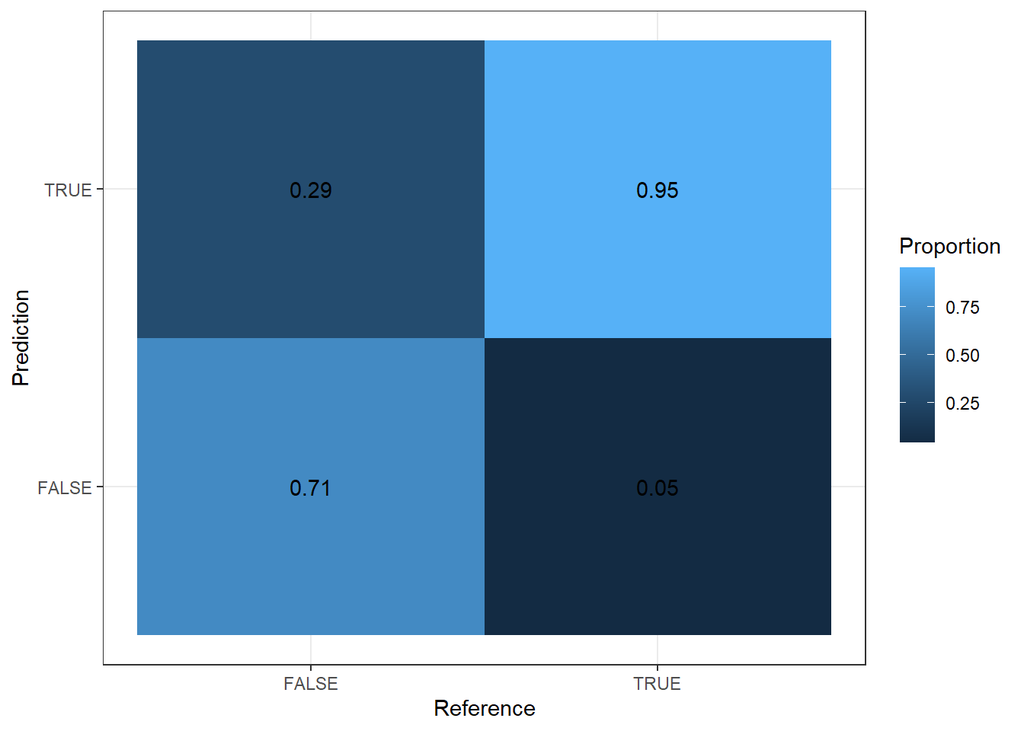

```r
cm <- eval_nb(mod_nb_db, X_test_d, y_test_b)$table
cm[,1] = cm[,1] / sum(cm[,1])
cm[,2] = cm[,2] / sum(cm[,2])
cm <- cm %>% melt() %>% rename(Proportion=value)

ggplot(cm, aes(Reference, Prediction, fill=Proportion))+
  geom_tile()+
  geom_text(aes(label=round(Proportion,2)))+
  theme_bw()
```

```r
coefs <- coef(mod_nb_db) %>% data.frame() %>% rename(False=FALSE., True=TRUE.)
coefs <- cbind(Term = rownames(coefs), coefs) %>% mutate(tf_ratio=True/False)
coefs <- rbind(
  coefs %>% arrange(desc(tf_ratio)) %>% slice_head(n=30), # top pos
  coefs %>% arrange(tf_ratio) %>% slice_head(n=30) # top neg
)
coefs <- coefs %>% filter(!(Term %in% c('degenhardt','raffinan','hojraj','wang','milani','oh','samson')))
#coefs <- coefs[1:20,]
coefs
```

|  | Term | False | True | tf_ratio |
| --- | --- | --- | --- | --- |
| wonderful | wonderful | 6.570590e-05 | 1.489909e-03 | 22.67542553 |
| thoughtful | thoughtful | 2.190197e-05 | 4.289133e-04 | 19.58332205 |
| approachable | approachable | 2.190197e-05 | 4.289133e-04 | 19.58332205 |
| forward | forward | 4.380393e-05 | 7.449546e-04 | 17.00656915 |
| informative | informative | 8.760787e-05 | 1.331889e-03 | 15.20284211 |
| excellent | excellent | 1.752157e-04 | 2.618628e-03 | 14.94516682 |
| easy | easy | 2.190197e-04 | 2.776649e-03 | 12.67762427 |
| awesome | awesome | 6.570590e-05 | 8.126778e-04 | 12.36841392 |
| considerate | considerate | 2.190197e-05 | 2.257438e-04 | 10.30701160 |
| reassure | reassure | 2.190197e-05 | 2.257438e-04 | 10.30701160 |

[output cut: 43 more lines]

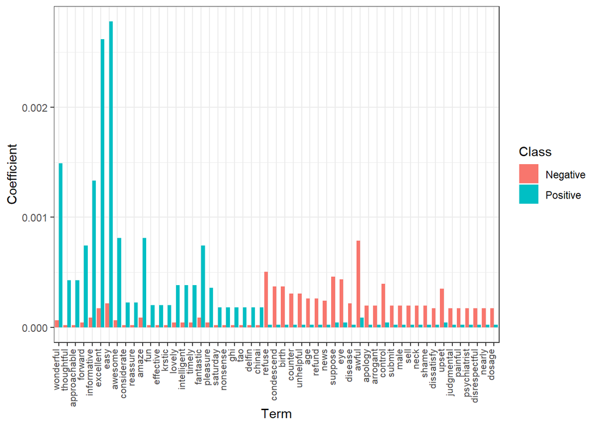

```r
coefs_g <- coefs[,1:3] %>% gather(Class, Coefficient, -Term) %>% mutate(Class=ifelse(Class=='False', 'Negative', 'Positive'))
coefs_g$Term <- factor(coefs_g$Term, levels=unique(coefs_g$Term))
ggplot(coefs_g, aes(Term, Coefficient, fill=Class))+
  geom_col(position='dodge')+
  theme_bw()+
  theme(axis.text.x = element_text(angle = 90, vjust = 0, hjust=1, size=8))
```

```r
coefs2 <- coef(mod_nb_db) %>% data.frame() %>% rename(False=FALSE., True=TRUE.)
coefs2 <- cbind(Term = rownames(coefs2), coefs2) %>% mutate(tf_ratio=True/False) %>% mutate(adj_tf_ratio_pos=tf_ratio*True, adj_tf_ratio_neg=tf_ratio/False)
coefs2 <- rbind(
  coefs2 %>% arrange(desc(adj_tf_ratio_pos)) %>% slice_head(n=15), # top pos
  coefs2 %>% arrange(adj_tf_ratio_neg) %>% slice_head(n=15) # top neg
)

coefs2
```

|  | Term | False | True | tf_ratio | adj_tf_ratio_pos | adj_tf_ratio_neg |
| --- | --- | --- | --- | --- | --- | --- |
| great | great | 2.146393e-03 | 1.164838e-02 | 5.42695713 | 6.321527e-02 | 2528.40825 |
| professional | professional | 1.533138e-03 | 8.849158e-03 | 5.77192650 | 5.107669e-02 | 3764.78029 |
| dr | dr | 1.011871e-02 | 2.191973e-02 | 2.16625720 | 4.748376e-02 | 214.08435 |
| thorough | thorough | 9.417846e-04 | 6.546571e-03 | 6.95124038 | 4.550679e-02 | 7380.92403 |
| good | good | 5.541198e-03 | 1.492167e-02 | 2.69285955 | 4.018195e-02 | 485.97068 |
| excellent | excellent | 1.752157e-04 | 2.618628e-03 | 14.94516682 | 3.913584e-02 | 85295.80336 |
| friendly | friendly | 1.357922e-03 | 7.020633e-03 | 5.17013001 | 3.629759e-02 | 3807.38381 |
| easy | easy | 2.190197e-04 | 2.776649e-03 | 12.67762427 | 3.520131e-02 | 57883.49690 |
| wonderful | wonderful | 6.570590e-05 | 1.489909e-03 | 22.67542553 | 3.378433e-02 | 345104.85957 |
| helpful | helpful | 8.979806e-04 | 4.424579e-03 | 4.92725433 | 2.180103e-02 | 5487.03849 |

[output cut: 20 more lines]

**Random Forest with downsampling and binarizing**

Run setup cells above (For notebook, modeling)

SETUP CELL FOR RF

```r
library(randomForest)
# Need to redo downsampling since before I just used train/test, not train/val/test

set.seed(111)
downsampled_id <- which(y_train == 5) %>% sample(1000)
downsampled_id <- c(which(y_train < 5), downsampled_id)
downsampled_id <- id_train[downsampled_id]

X_train_rf <- reviews[downsampled_id,]$Review %>% make_dfm()
y_train_rf <- factor(reviews$OverallRating[downsampled_id] >= 4)
# Remember, val and test X stay the same as the true distribution.
# Just need to binarize y
y_val_rf <- factor(y_val >= 4)
y_test_rf <- factor(y_test >= 4)

# Convert val and test dfm's to matrix, as randomForest isn't part of quanteda. Also feature match them as X_train may now be missing some features
X_val_rf <- X_val %>% dfm_match(featnames(X_train_rf)) %>% convert("matrix")
X_test_rf <- X_test %>% dfm_match(featnames(X_train_rf)) %>% convert("matrix")
X_train_rf <- X_train_rf %>% convert("matrix")
```

NOTE: I comment out certain lines below for convenience when knitting

```r
# First do hyperparameter tuning
nc <- ncol(X_train_rf)
params_rf <- expand.grid(
  c(100,200,500),
  c(0.75*sqrt(nc), sqrt(nc), 1.25*sqrt(nc)) %>% floor()
) %>% as.data.frame()
colnames(params_rf) <- c('ntree','mtry')

res <- c(0)
print(paste("Beginning", nrow(params_rf), "iterations."))
```

```
## [1] "Beginning 9 iterations."
```

```r
# for (i in 1:nrow(params_rf)) {
#   print(i)
#   p <- params_rf[i,]
#   rf <- randomForest(x = X_train_rf, y = y_train_rf,
#                      importance = TRUE,
#                      ntree=p[1] %>% pull(),
#                      mtry=p[2] %>% pull())
#   preds <- predict(rf, newdata=X_val_rf)
#   res[i] <- mean(preds == y_val_rf)
# }
# amax_res <- which(res == max(res))
# paste("Best paramaters:", params_rf[amax_res,])
# paste("Accuracy:", max(res))
```

Best params: 500 trees, 68 (sqrt(nc)) mtry. Defaults are defaults for a reason.

```r
library(caret)
# rf <- randomForest(x = rbind(X_train_rf, X_val_rf),
#                    y = c(y_train_rf, y_val_rf),
#                    importance = TRUE
#                    )
#save(rf, file="rf.Rdata")
load('C:/Users/arzaa/teda_project/rf.Rdata')
preds <- predict(rf, newdata=X_test_rf)
confusionMatrix(y_test_rf, preds)
```

```
## Confusion Matrix and Statistics
##
##           Reference
## Prediction FALSE TRUE
##      FALSE   199  309
##      TRUE     49 6032
##
##                Accuracy : 0.9457
##                  95% CI : (0.9399, 0.951)
##     No Information Rate : 0.9624
##     P-Value [Acc > NIR] : 1
##
##                   Kappa : 0.5012
##
##  Mcnemar's Test P-Value : <2e-16
##
##             Sensitivity : 0.80242
##             Specificity : 0.95127
##          Pos Pred Value : 0.39173
##          Neg Pred Value : 0.99194
##              Prevalence : 0.03764
##          Detection Rate : 0.03020
##    Detection Prevalence : 0.07710
##       Balanced Accuracy : 0.87684
##
##        'Positive' Class : FALSE
##
```

```r
token_imp <- round(importance(rf, 2), 2) %>% as.data.frame() %>% arrange(desc(MeanDecreaseGini))
token_imp$token <- row.names(token_imp)
token_imp[1:20,]
```

|  | MeanDecreaseGini | token |
| --- | --- | --- |
| tell | 27.30 | tell |
| rude | 22.58 | rude |
| unprofessional | 21.41 | unprofessional |
| bad | 18.48 | bad |
| horrible | 16.68 | horrible |
| hour | 15.89 | hour |
| even | 15.46 | even |
| dr | 15.40 | dr |
| never | 14.57 | never |
| get | 13.39 | get |

[output cut: 10 more lines]

Plotting RF confusion matrix:

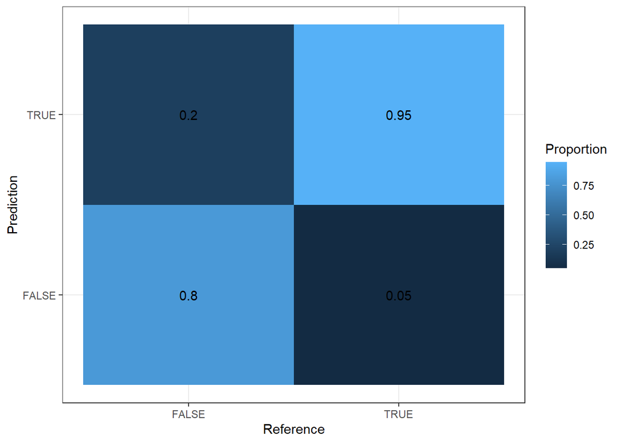

```r
library(ggplot2)

load('C:/Users/arzaa/teda_project/rf.Rdata')
preds <- predict(rf, newdata=X_test_rf)
cm <- confusionMatrix(y_test_rf, preds)$table
cm[,1] = cm[,1] / sum(cm[,1])
cm[,2] = cm[,2] / sum(cm[,2])
cm <- cm %>% melt() %>% rename(Proportion=value)


ggplot(cm, aes(Reference, Prediction, fill=Proportion))+
  geom_tile()+
  geom_text(aes(label=round(Proportion,2)))+
  theme_bw()
```